# **섹션 1: 소개: 약간의 역사**

# **Alphafold 소개!**

##[홈페이지로 돌아가기](https://github.com/Graylab/DL4Proteins-notebooks)

AlphaFold2의 구현은 [ColabFold](https://colab.research.google.com/github/sokrypton/ColabFold/blob/main/AlphaFold2.ipynb#scrollTo=11l8k--10q0C)에서 각색되었습니다.

**목표: 이 워크숍을 마치면 다음을 수행할 수 있습니다:**

- 최신 단백질 접힘 및 멀티트랙 아키텍처 식별 및 적용
- AF2의 ColabFold 구현 실행
- pLDDT 점수, coverage, pae 점수를 포함한 AF 출력 해석
- AlphaFold의 다양한 단백질 표현 구별
- AF2의 기본 아키텍처 구성 요소 열거

*작업 내용을 저장하려면 이 노트북의 사본을 개인 Google 드라이브에 저장하세요.*

## **목차:**

#### **[섹션 1: 소개](https://colab.research.google.com/drive/1eDrb1ZvvpzhTLyjGi8KGUc-oDpMz042g#scrollTo=ZNmOoXn3MooL&line=1&uniqifier=1)**

- [소개: 딥러닝의 등장!](https://colab.research.google.com/drive/1eDrb1ZvvpzhTLyjGi8KGUc-oDpMz042g#scrollTo=vgLg8ZuqMrNm)
- [소개: 마법 상자로서의 Alphafold](https://colab.research.google.com/drive/1eDrb1ZvvpzhTLyjGi8KGUc-oDpMz042g#scrollTo=cuKGEbS3M1XV)

#### **[섹션 2: 실용적인 Alphafold](https://colab.research.google.com/drive/1eDrb1ZvvpzhTLyjGi8KGUc-oDpMz042g#scrollTo=PchvZcXB_EED&line=1&uniqifier=1)**

- [실용적인 Alphafold: 서열 접기](https://colab.research.google.com/drive/1eDrb1ZvvpzhTLyjGi8KGUc-oDpMz042g#scrollTo=zFiu3-77Lwv3)
- [실용적인 Alphafold: 결과 해석](https://colab.research.google.com/drive/1eDrb1ZvvpzhTLyjGi8KGUc-oDpMz042g#scrollTo=XA1chQuQHlOy)
- [다중 서열 정렬(MSA) Coverage](https://colab.research.google.com/drive/1eDrb1ZvvpzhTLyjGi8KGUc-oDpMz042g#scrollTo=RqdPucMuBJc6)
- [pLDDT](https://colab.research.google.com/drive/1eDrb1ZvvpzhTLyjGi8KGUc-oDpMz042g#scrollTo=2p_9NU3aLO6o)
- [예측 정렬 오류(PAE)](https://colab.research.google.com/drive/1eDrb1ZvvpzhTLyjGi8KGUc-oDpMz042g#scrollTo=g7VWwNOdQ1Mb)

#### **[섹션 3: Alphafold 아키텍처](https://colab.research.google.com/drive/1eDrb1ZvvpzhTLyjGi8KGUc-oDpMz042g#scrollTo=5uBuxvaA5eBZ)**

- [Alphafold 아키텍처: 입력 서열 표현](https://colab.research.google.com/drive/1eDrb1ZvvpzhTLyjGi8KGUc-oDpMz042g#scrollTo=wuH9nL9fHqFx)
- [Alphafold 아키텍처: Evoformer](https://colab.research.google.com/drive/1eDrb1ZvvpzhTLyjGi8KGUc-oDpMz042g#scrollTo=_lGBhd6VIw3U)
- [Alphafold 아키텍처: 구조 모듈](https://colab.research.google.com/drive/1eDrb1ZvvpzhTLyjGi8KGUc-oDpMz042g#scrollTo=Biq7NEcUJtaw)

### **라이브러리 임포트**

```python
#@markdown **Please run this cell as you read the introduction**
from google.colab import files
import os
import re
import hashlib
import random
from PIL import Image
import matplotlib.pyplot as plt

from sys import version_info
python_version = f"{version_info.major}.{version_info.minor}"

import os

custom_template_path = None
use_templates = False


USE_AMBER = False
USE_TEMPLATES = use_templates
PYTHON_VERSION = python_version

if not os.path.isfile("COLABFOLD_READY"):
  print("installing colabfold...")
  os.system("pip install -q --no-warn-conflicts 'colabfold[alphafold-minus-jax] @ git+https://github.com/sokrypton/ColabFold'")
  if os.environ.get('TPU_NAME', False) != False:
    os.system("pip uninstall -y jax jaxlib")
    os.system("pip install --no-warn-conflicts --upgrade dm-haiku==0.0.10 'jax[cuda12_pip]'==0.3.25 -f https://storage.googleapis.com/jax-releases/jax_cuda_releases.html")
  os.system("ln -s /usr/local/lib/python3.*/dist-packages/colabfold colabfold")
  os.system("ln -s /usr/local/lib/python3.*/dist-packages/alphafold alphafold")
  os.system("touch COLABFOLD_READY")

if USE_AMBER or USE_TEMPLATES:
  if not os.path.isfile("CONDA_READY"):
    print("installing conda...")
    os.system("wget -qnc https://github.com/conda-forge/miniforge/releases/latest/download/Mambaforge-Linux-x86_64.sh")
    os.system("bash Mambaforge-Linux-x86_64.sh -bfp /usr/local")
    os.system("mamba config --set auto_update_conda false")
    os.system("touch CONDA_READY")

if USE_TEMPLATES and not os.path.isfile("HH_READY") and USE_AMBER and not os.path.isfile("AMBER_READY"):
  print("installing hhsuite and amber...")
  os.system(f"mamba install -y -c conda-forge -c bioconda kalign2=2.04 hhsuite=3.3.0 openmm=7.7.0 python='{PYTHON_VERSION}' pdbfixer")
  os.system("touch HH_READY")
  os.system("touch AMBER_READY")
else:
  if USE_TEMPLATES and not os.path.isfile("HH_READY"):
    print("installing hhsuite...")
    os.system(f"mamba install -y -c conda-forge -c bioconda kalign2=2.04 hhsuite=3.3.0 python='{PYTHON_VERSION}'")
    os.system("touch HH_READY")
  if USE_AMBER and not os.path.isfile("AMBER_READY"):
    print("installing amber...")
    os.system(f"mamba install -y -c conda-forge openmm=7.7.0 python='{PYTHON_VERSION}' pdbfixer")
    os.system("touch AMBER_READY")

import sys
import warnings
warnings.simplefilter(action='ignore', category=FutureWarning)
from Bio import BiopythonDeprecationWarning
warnings.simplefilter(action='ignore', category=BiopythonDeprecationWarning)
from pathlib import Path
from colabfold.download import download_alphafold_params, default_data_dir
from colabfold.utils import setup_logging
from colabfold.batch import get_queries, run, set_model_type
from colabfold.plot import plot_msa_v2

import os
import numpy as np
try:
  K80_chk = os.popen('nvidia-smi | grep "Tesla K80" | wc -l').read()
except:
  K80_chk = "0"
  pass
if "1" in K80_chk:
  print("WARNING: found GPU Tesla K80: limited to total length < 1000")
  if "TF_FORCE_UNIFIED_MEMORY" in os.environ:
    del os.environ["TF_FORCE_UNIFIED_MEMORY"]
  if "XLA_PYTHON_CLIENT_MEM_FRACTION" in os.environ:
    del os.environ["XLA_PYTHON_CLIENT_MEM_FRACTION"]

def add_hash(x,y):
  return x+"_"+hashlib.sha1(y.encode()).hexdigest()[:5]

jobname = 'import_test'
query_sequence = 'A'
basejobname = "".join(jobname.split())
basejobname = re.sub(r'\W+', '', basejobname)
jobname = add_hash(basejobname, query_sequence)

# check if directory with jobname exists
def check(folder):
  if os.path.exists(folder):
    return False
  else:
    return True
if not check(jobname):
  n = 0
  while not check(f"{jobname}_{n}"): n += 1
  jobname = f"{jobname}_{n}"

# make directory to save results
os.makedirs(jobname, exist_ok=True)

# save queries
queries_path = os.path.join(jobname, f"{jobname}.csv")
with open(queries_path, "w") as text_file:
  text_file.write(f"id,sequence\n{jobname},{query_sequence}")

from colabfold.colabfold import plot_protein
from pathlib import Path
import matplotlib.pyplot as plt

def input_features_callback(input_features):
  if display_images:
    plot_msa_v2(input_features)
    plt.show()
    plt.close()

def prediction_callback(protein_obj, length,
                        prediction_result, input_features, mode):
  model_name, relaxed = mode
  if not relaxed:
    if display_images:
      fig = plot_protein(protein_obj, Ls=length, dpi=150)
      plt.show()
      plt.close()
model_type = "auto"
queries, is_complex = get_queries(queries_path)
model_type = set_model_type(is_complex, model_type)
download_alphafold_params(model_type, Path("."))
```

```
installing colabfold...
```

```
Downloading alphafold2_ptm weights to .: 100%|██████████| 3.47G/3.47G [02:01<00:00, 30.6MB/s]
```

단백질의 서열을 안다면 어떤 3D 구조로 접힐까요? 이 단백질 접힘 문제는 생물물리학자, 생물학자, 단백질 공학자들의 오랜 꿈이었습니다. 이를 해결하는 것은 연구 및 약물 설계를 위한 많은 새로운 발견과 혁신의 열쇠를 쥐고 있습니다!

[figure not shown]

## **등장: 딥러닝!**

하지만 단백질 접힘 뒤에 있는 개별 물리적 개념의 대부분을 이해했음에도 불구하고 단백질이 무엇으로 접힐지 확실하게 예측할 수 있는 방정식 레시피는 없었습니다.

3D 실험 단백질 구조의 예가 증가함에 따라 데이터셋은 결국 신경망이 단백질이 접히는 방식을 예측하도록 훈련할 수 있을 만큼 커졌습니다.

[figure not shown]

### **질문: AF1과 AF2가 2018년 및 2020년 CASP 벤치마크의 중간 정확도(median percent accuracy)에 어떤 영향을 미쳤다고 생각합니까?**

힌트: 이전 점수는 약 30-40 Global Distance Score(100점 만점)였습니다.

```python
# @markdown Take a guess!
AF1 = 70 # @param {type:"slider", min:0, max:100, step:10}
AF2 = 50 # @param {type:"slider", min:0, max:100, step:10}

year = [2006, 2008, 2010, 2012, 2014, 2016, 2018, 2020]
casp_scores = [35, 41, 34, 30, 31, 41, 57, 88]

# make bar chart
fig = plt.figure(figsize=(10, 5))
plt.bar(year, casp_scores)
plt.xlabel('Year')
plt.ylabel('CASP Score')

# add prediction as scatter
plt.scatter(2018, AF1, label='AF1', color='purple')
plt.scatter(2020, AF2, label='AF2', color='magenta')
plt.text(2018, AF1, f'{AF1}', ha='right')
plt.text(2020, AF2, f'{AF2}', ha='right')
plt.title('CASP Median Free Modeling Accuracy')

# Set y axis to 0-100
plt.ylim(0, 100)


plt.show()
```

[output not shown]

## **마법 상자로서의 AlphaFold**

AlphaFold는 입력으로 서열과 몇 가지 선택적인 다른 정보를 사용합니다:

1. MSAs – 다중 서열 정렬, 데이터베이스에서 추론된 유전적으로 유사한 아미노산 서열.
2. Pair Features – 가능한 잔기 상호 작용의 쌍별 특징 표현.
3. Templates – 알려지지 않은 단백질과 구조가 유사할 수 있는 템플릿 단백질. 이들은 모델의 주요 모듈에 들어가기 전에 쌍 특징과 결합됩니다.

간단히 말해서, 이 세 가지 입력이 모델에 공급되면 모델은 단백질과 AF가 구조가 얼마나 그럴듯하다고 생각하는지에 대한 몇 가지 지표를 뱉어냅니다. 자세한 내용은 **AF 아키텍처: AF는 어떻게 작동합니까?** 하위 섹션을 참조하세요.

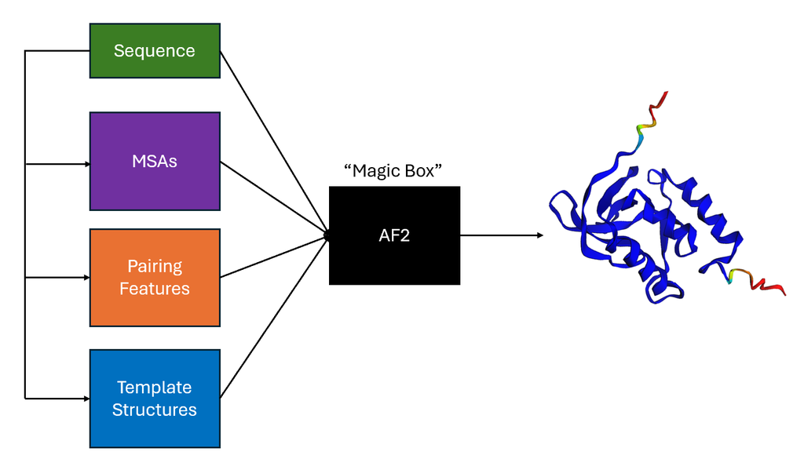

# **섹션 2: 실용적인 AF – 단백질 접기 (ColabFold)**

바로 들어가 봅시다! 단백질 서열이 있습니다. AlphaFold로 구조를 어떻게 찾을까요?

여기서는 AF2의 ColabFold 구현([Mirdita et al. 2022](https://www.nature.com/articles/s41592-022-01488-1))을 사용할 것입니다. 일반적으로 MSA 정렬을 제공해야 하지만 ColabFold는 MMseqs2를 사용하여 자동으로 수행합니다. 아래 셀을 실행하고 서열(및 선택적으로 템플릿)을 제공하기만 하면 짠, 단백질이 접힙니다!

참고: 드노보(de novo) 단백질을 설계할 때는 MSA를 끄는 것이 좋습니다. 드노보 단백질은 일반적으로 천연 단백질과 구조적 유사성이 높지 않기 때문입니다.

각색된 내용입니다. 더 고급 용도의 경우 [ColabFold Github](https://github.com/sokrypton/ColabFold) 페이지를 방문하여 더 많은 옵션과 매개변수가 있는 노트북을 찾으세요. 이 노트북은 주로 교육 목적으로 제작되었습니다!